# r4ds_ps6

Annie Gao

2/25/2018

# Prelim questions

## 1

I worked with Umer Naeem.

## 2

I spent 10 hours on this part and 20 hours waiting for code to run on the Transit portion.

# 1 R4DS Chapter 15

## 1

```r
x <- c("Dec", "Apr", "Jan", "Mar")

factor(x, levels = unique(x))
```

```
## [1] Dec Apr Jan Mar
## Levels: Dec Apr Jan Mar
```

```r
factor(x, levels = x)
```

```
## [1] Dec Apr Jan Mar
## Levels: Dec Apr Jan Mar
```

```r
x_dups <- c("Dec", "Apr", "Jan", "Mar", "Mar", "Dec")

factor(x_dups, levels = unique(x_dups))
```

```
## [1] Dec Apr Jan Mar Mar Dec
## Levels: Dec Apr Jan Mar
```

```r
#factor(x_dups, levels = x_dups) commented because will return factor level duplicate error
```

The first output with unique produces the same output as the second without the unique operator. All the x values are unique already and therefore did not require the unique operator. In the vector x_dups, including the unique operator returns non-duplicate levels. Without the unique operator, R throws an error saying that levels are duplicates.

## 2

```r
forcats::gss_cat
```

```
## # A tibble: 21,483 x 9
##     year marital         age race  rincome  partyid  relig  denom  tvhours
##    <int> <fct>         <int> <fct> <fct>    <fct>    <fct>  <fct>    <int>
##  1  2000 Never married    26 White $8000 t… Ind,nea… Prote… South…      12
##  2  2000 Divorced         48 White $8000 t… Not str… Prote… Bapti…      NA
##  3  2000 Widowed          67 White Not app… Indepen… Prote… No de…       2
##  4  2000 Never married    39 White Not app… Ind,nea… Ortho… Not a…       4
##  5  2000 Divorced         25 White Not app… Not str… None   Not a…       1
##  6  2000 Married          25 White $20000 … Strong … Prote… South…      NA
##  7  2000 Never married    36 White $25000 … Not str… Chris… Not a…       3
##  8  2000 Divorced         44 White $7000 t… Ind,nea… Prote… Luthe…      NA
##  9  2000 Married          44 White $25000 … Not str… Prote… Other        0
## 10  2000 Married          47 White $25000 … Strong … Prote… South…       3
## # ... with 21,473 more rows
```

```r
summary(gss_cat)
```

```
##       year               marital           age
##  Min.   :2000   No answer    :   17   Min.   :18.00
##  1st Qu.:2002   Never married: 5416   1st Qu.:33.00
##  Median :2006   Separated    :  743   Median :46.00
##  Mean   :2007   Divorced     : 3383   Mean   :47.18
##  3rd Qu.:2010   Widowed      : 1807   3rd Qu.:59.00
##  Max.   :2014   Married      :10117   Max.   :89.00
##                                       NA's   :76
##              race                 rincome                   partyid
##  Other         : 1959   $25000 or more:7363   Independent       :4119
##  Black         : 3129   Not applicable:7043   Not str democrat  :3690
##  White         :16395   $20000 - 24999:1283   Strong democrat   :3490
##  Not applicable:    0   $10000 - 14999:1168   Not str republican:3032
##                         $15000 - 19999:1048   Ind,near dem      :2499
##                         Refused       : 975   Strong republican :2314
##                         (Other)       :2603   (Other)           :2339
##         relig                    denom          tvhours
##  Protestant:10846   Not applicable  :10072   Min.   : 0.000
##  Catholic  : 5124   Other           : 2534   1st Qu.: 1.000
##  None      : 3523   No denomination : 1683   Median : 2.000
##  Christian :  689   Southern baptist: 1536   Mean   : 2.981
##  Jewish    :  388   Baptist-dk which: 1457   3rd Qu.: 4.000
##  Other     :  224   United methodist: 1067   Max.   :24.000
##  (Other)   :  689   (Other)         : 3134   NA's   :10146
```

```r
levels(forcats::gss_cat$rincome)
```

```
##  [1] "No answer"      "Don't know"     "Refused"        "$25000 or more"
##  [5] "$20000 - 24999" "$15000 - 19999" "$10000 - 14999" "$8000 to 9999"
##  [9] "$7000 to 7999"  "$6000 to 6999"  "$5000 to 5999"  "$4000 to 4999"
## [13] "$3000 to 3999"  "$1000 to 2999"  "Lt $1000"       "Not applicable"
```

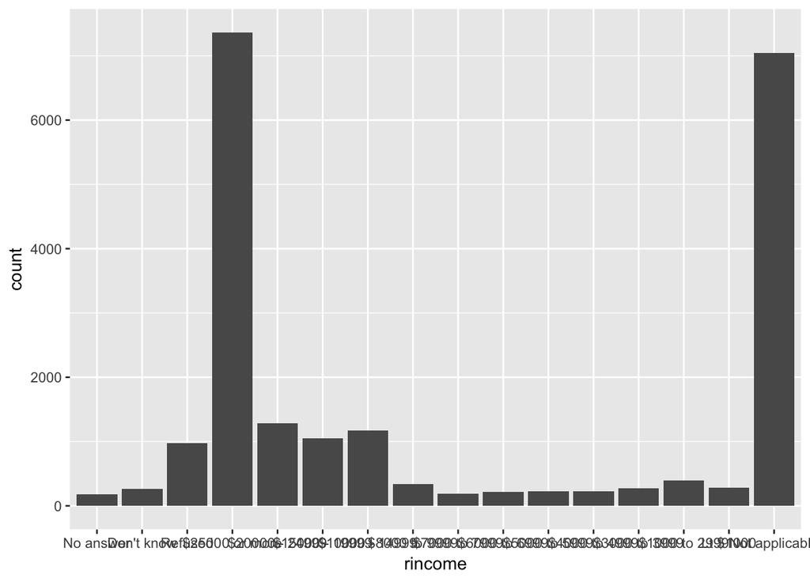

```r
ggplot(gss_cat, mapping = aes(rincome)) +
  geom_bar()
```

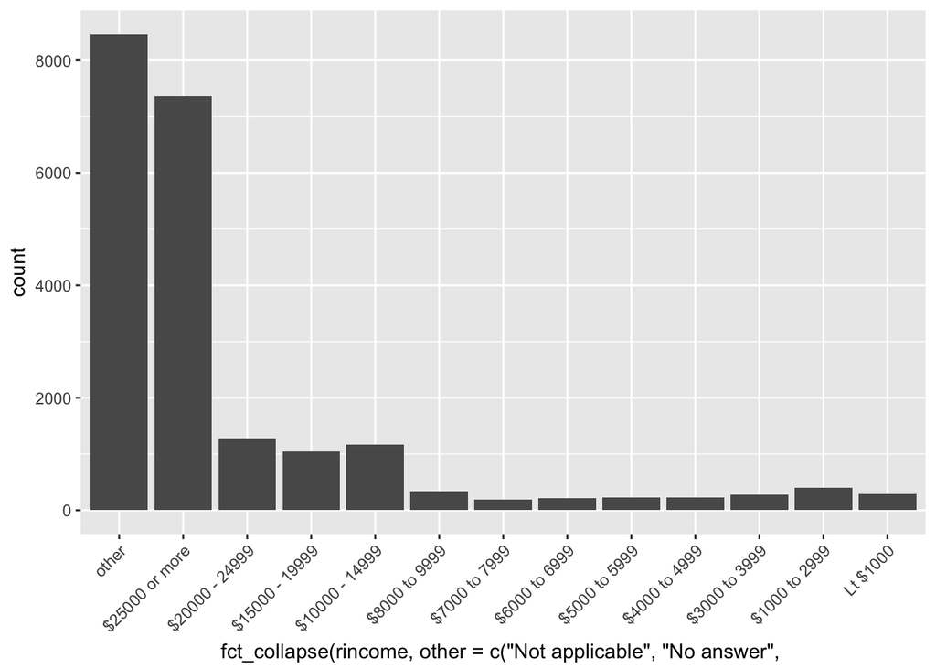

```r
#two improvements
ggplot(gss_cat, mapping = aes(fct_collapse(rincome, other = c("Not applicable",
                                                                "No answer",
                                                                "Don't know",
                                                                "Refused")))) +
  geom_bar() +
  theme(axis.text.x = element_text(angle = 45, hjust = 1))
```

## 3

```r
gss_cat %>%
  count(relig) %>%
  arrange(desc(n))
```

```
## # A tibble: 15 x 2
##    relig                       n
##    <fct>                   <int>
##  1 Protestant              10846
##  2 Catholic                 5124
##  3 None                     3523
##  4 Christian                 689
##  5 Jewish                    388
##  6 Other                     224
##  7 Buddhism                  147
##  8 Inter-nondenominational   109
##  9 Moslem/islam              104
## 10 Orthodox-christian         95
## 11 No answer                  93
## 12 Hinduism                   71
## 13 Other eastern              32
## 14 Native american            23
## 15 Don't know                 15
```

```r
gss_cat %>%
  count(partyid) %>%
  arrange(desc(n))
```

```
## # A tibble: 10 x 2
##    partyid                n
##    <fct>              <int>
##  1 Independent         4119
##  2 Not str democrat    3690
##  3 Strong democrat     3490
##  4 Not str republican  3032
##  5 Ind,near dem        2499
##  6 Strong republican   2314
##  7 Ind,near rep        1791
##  8 Other party          393
##  9 No answer            154
## 10 Don't know             1
```

The most common religion in this dataset is Protestant. The most common partid is Independent.

## 4

```r
levels(gss_cat$relig)
```

```
##  [1] "No answer"               "Don't know"
##  [3] "Inter-nondenominational" "Native american"
##  [5] "Christian"               "Orthodox-christian"
##  [7] "Moslem/islam"            "Other eastern"
##  [9] "Hinduism"                "Buddhism"
## [11] "Other"                   "None"
## [13] "Jewish"                  "Catholic"
## [15] "Protestant"              "Not applicable"
```

```r
levels(gss_cat$denom)
```

```
##  [1] "No answer"            "Don't know"           "No denomination"
##  [4] "Other"                "Episcopal"            "Presbyterian-dk wh"
##  [7] "Presbyterian, merged" "Other presbyterian"   "United pres ch in us"
## [10] "Presbyterian c in us" "Lutheran-dk which"    "Evangelical luth"
## [13] "Other lutheran"       "Wi evan luth synod"   "Lutheran-mo synod"
## [16] "Luth ch in america"   "Am lutheran"          "Methodist-dk which"
## [19] "Other methodist"      "United methodist"     "Afr meth ep zion"
## [22] "Afr meth episcopal"   "Baptist-dk which"     "Other baptists"
## [25] "Southern baptist"     "Nat bapt conv usa"    "Nat bapt conv of am"
## [28] "Am bapt ch in usa"    "Am baptist asso"      "Not applicable"
```

```r
#method 1
dont_know <- c("No answer", "Other", "Don't know",
               "Not applicable", "No denomination")

relig_denom_kable <- gss_cat %>%
  filter(!denom %in% dont_know) %>%
  count(relig, denom) %>%
  arrange(desc(n))

knitr::kable(relig_denom_kable, "markdown") %>%
  kable_styling(bootstrap_options = c("striped", "hover", "condensed"))
```

| relig | denom | n |
| --- | --- | --- |
| Protestant | Southern baptist | 1536 |
| Protestant | Baptist-dk which | 1457 |
| Protestant | United methodist | 1067 |
| Protestant | Episcopal | 397 |
| Protestant | Lutheran-dk which | 267 |
| Protestant | Presbyterian-dk wh | 244 |
| Protestant | Methodist-dk which | 239 |
| Protestant | Am baptist asso | 237 |
| Protestant | Other baptists | 213 |
| Protestant | Lutheran-mo synod | 212 |
| Protestant | Am lutheran | 146 |
| Protestant | Am bapt ch in usa | 130 |
| Protestant | Evangelical luth | 122 |
| Protestant | United pres ch in us | 110 |
| Protestant | Presbyterian c in us | 104 |
| Protestant | Afr meth episcopal | 77 |
| Protestant | Nat bapt conv of am | 76 |
| Protestant | Wi evan luth synod | 71 |
| Protestant | Luth ch in america | 71 |
| Protestant | Presbyterian, merged | 67 |
| Protestant | Other presbyterian | 47 |
| Protestant | Nat bapt conv usa | 40 |
| Protestant | Other methodist | 33 |
| Protestant | Afr meth ep zion | 32 |
| Protestant | Other lutheran | 30 |

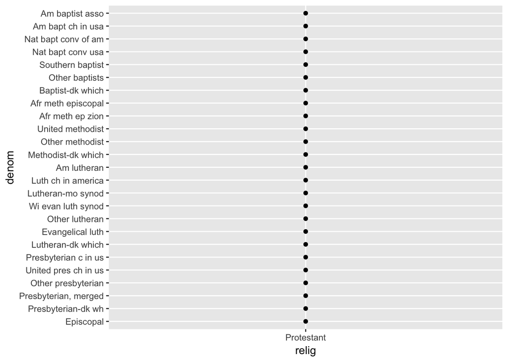

```r
#method 2
relig_denom <- gss_cat %>%
  filter(!denom %in% dont_know) %>%
  count(relig, denom)

ggplot(relig_denom, aes(x = relig, y = denom)) +
  geom_point()
```

Protestant is the only religion that the factor denom applies to after taking out no answers and other noninformative denom responses. Both the table and the visualization show that only Protestant is associated with a denomination.

## 5

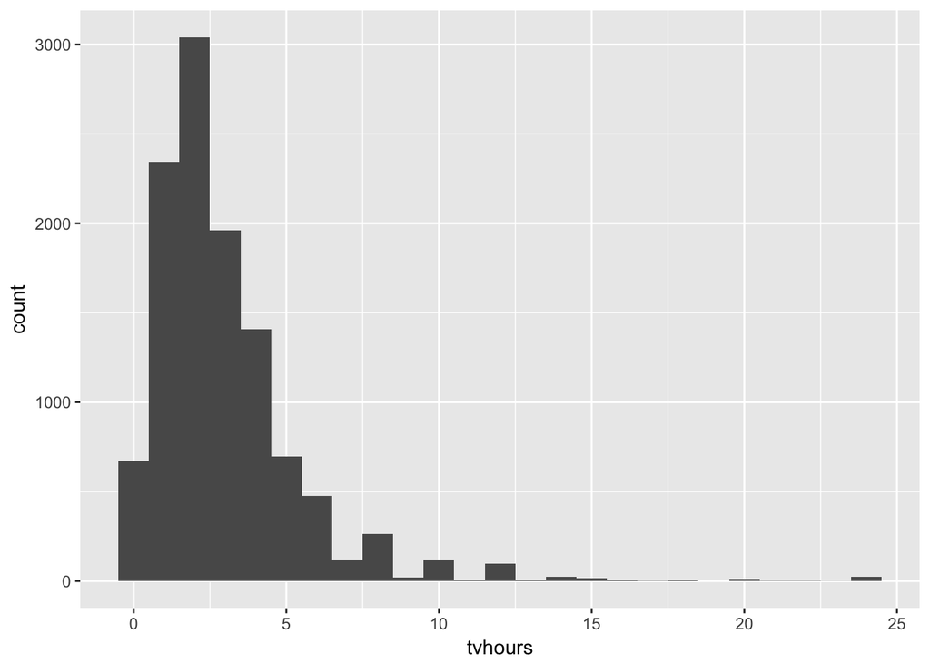

```r
ggplot(gss_cat, aes(x = tvhours)) +
  geom_histogram(binwidth = 1)
```

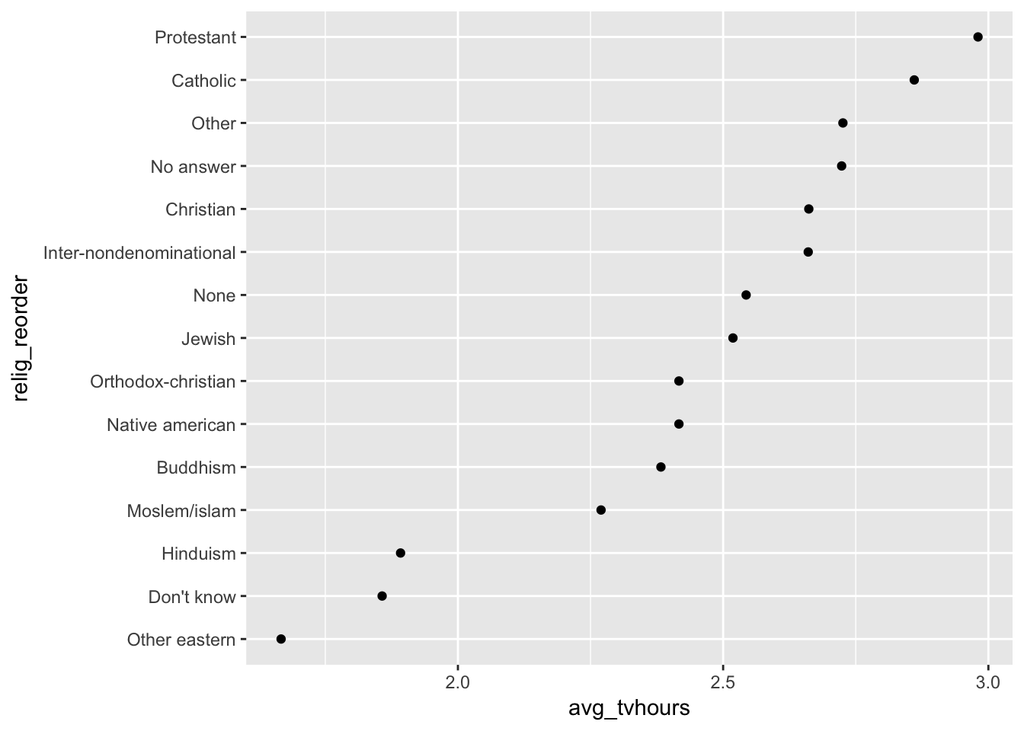

```r
#drop outliers
gss_cat_clean <- subset(gss_cat, tvhours <= 12 & !is.na(tvhours))

relig_summary <- gss_cat_clean %>%
  group_by(relig) %>%
  summarise(avg_tvhours = mean(tvhours, na.rm = TRUE),
            n = n())

relig_summary_reorder <- relig_summary %>%
  mutate(relig_reorder = fct_reorder(relig, avg_tvhours, median))

ggplot(relig_summary_reorder, aes(avg_tvhours, relig_reorder)) +
  geom_point()
```

Any number above 12 can be considered unreasonably high. We should drop these rows because if we’re trying to examine tv watching hours by religion, it would be misleading and erroneous to try to recode these outliers to another more reasonable hour because it forces the religion associated with the tv outlier to take on a different weight when examining tv hours. It causes the relationship between tv hours and religion to be imprecise. It seems that, on average, Protestants watch the highest number of hours of tv with Catholics at the second highest and other Eastern religions at the lowest number of hours of tv watching.

## 6

```r
levels(gss_cat$marital)
```

```
## [1] "No answer"     "Never married" "Separated"     "Divorced"
## [5] "Widowed"       "Married"
```

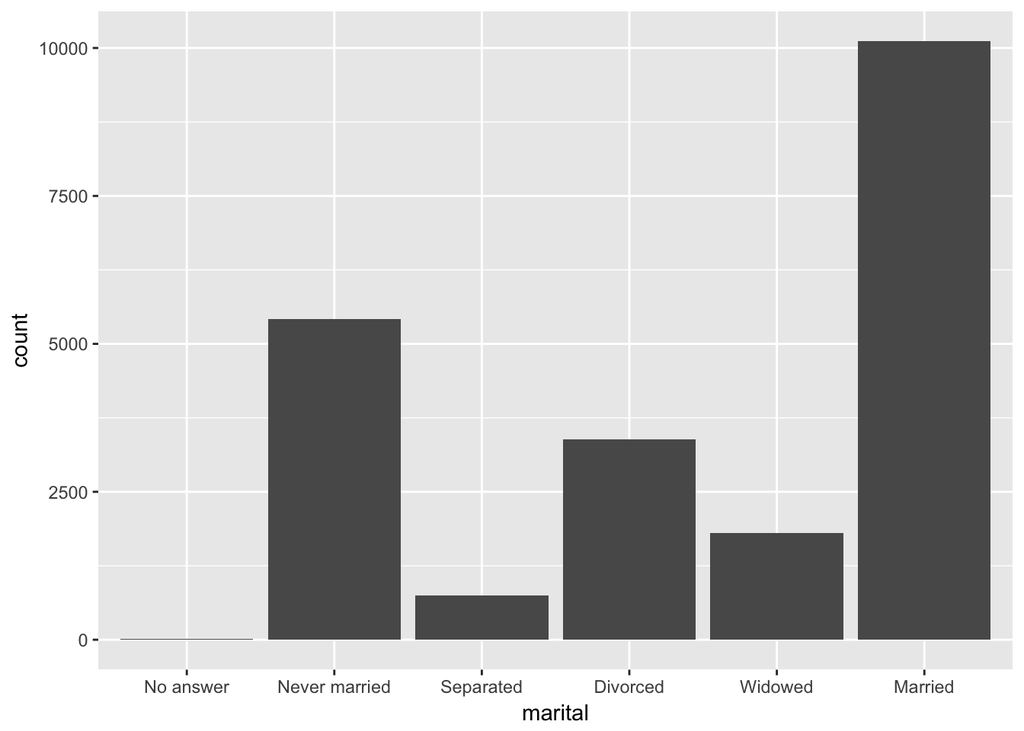

```r
ggplot(gss_cat, aes(marital)) +
  geom_bar()
```

```r
levels(gss_cat$race)
```

```
## [1] "Other"          "Black"          "White"          "Not applicable"
```

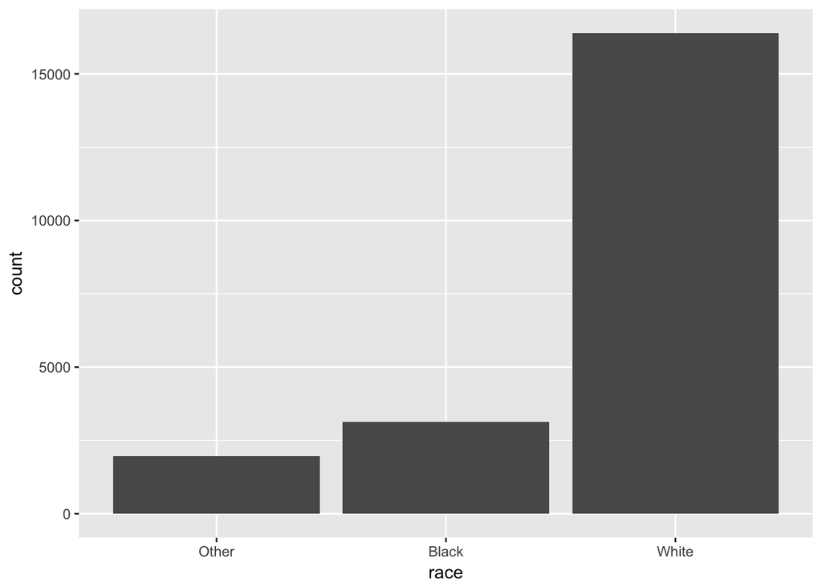

```r
ggplot(gss_cat, aes(race)) +
  geom_bar()
```

```r
levels(gss_cat$rincome)
```

```
##  [1] "No answer"      "Don't know"     "Refused"        "$25000 or more"
##  [5] "$20000 - 24999" "$15000 - 19999" "$10000 - 14999" "$8000 to 9999"
##  [9] "$7000 to 7999"  "$6000 to 6999"  "$5000 to 5999"  "$4000 to 4999"
## [13] "$3000 to 3999"  "$1000 to 2999"  "Lt $1000"       "Not applicable"
```

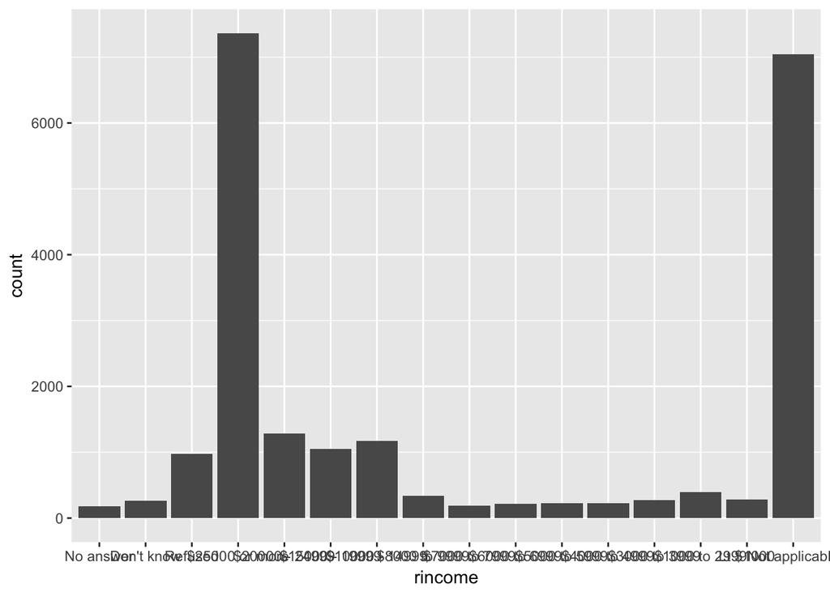

```r
ggplot(gss_cat, aes(rincome)) +
  geom_bar()
```

```r
levels(gss_cat$partyid)
```

```
##  [1] "No answer"          "Don't know"         "Other party"
##  [4] "Strong republican"  "Not str republican" "Ind,near rep"
##  [7] "Independent"        "Ind,near dem"       "Not str democrat"
## [10] "Strong democrat"
```

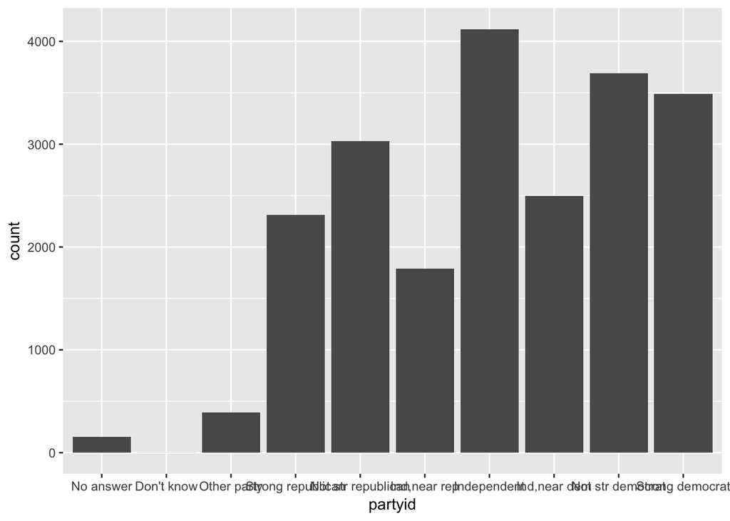

```r
ggplot(gss_cat, aes(partyid)) +
  geom_bar()
```

```r
levels(gss_cat$relig)
```

```
##  [1] "No answer"               "Don't know"
##  [3] "Inter-nondenominational" "Native american"
##  [5] "Christian"               "Orthodox-christian"
##  [7] "Moslem/islam"            "Other eastern"
##  [9] "Hinduism"                "Buddhism"
## [11] "Other"                   "None"
## [13] "Jewish"                  "Catholic"
## [15] "Protestant"              "Not applicable"
```

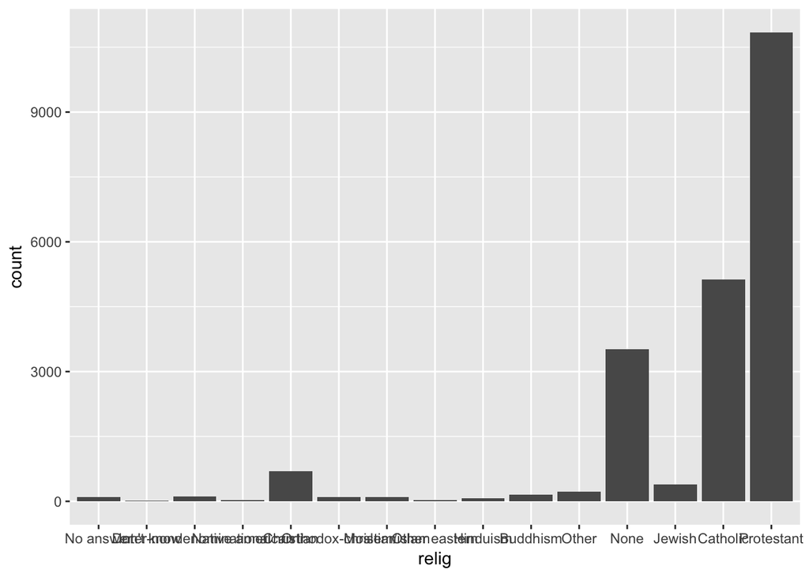

```r
ggplot(gss_cat, aes(relig)) +
  geom_bar()
```

```r
levels(gss_cat$denom)
```

```
##  [1] "No answer"            "Don't know"           "No denomination"
##  [4] "Other"                "Episcopal"            "Presbyterian-dk wh"
##  [7] "Presbyterian, merged" "Other presbyterian"   "United pres ch in us"
## [10] "Presbyterian c in us" "Lutheran-dk which"    "Evangelical luth"
## [13] "Other lutheran"       "Wi evan luth synod"   "Lutheran-mo synod"
## [16] "Luth ch in america"   "Am lutheran"          "Methodist-dk which"
## [19] "Other methodist"      "United methodist"     "Afr meth ep zion"
## [22] "Afr meth episcopal"   "Baptist-dk which"     "Other baptists"
## [25] "Southern baptist"     "Nat bapt conv usa"    "Nat bapt conv of am"
## [28] "Am bapt ch in usa"    "Am baptist asso"      "Not applicable"
```

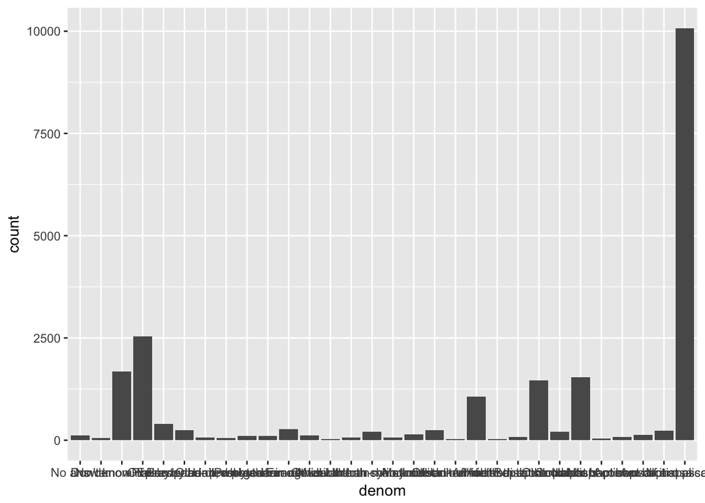

```r
ggplot(gss_cat, aes(denom)) +
  geom_bar()
```

For the marital factor, the levels are principled. The subdivisions are standard. For the the race factor, the levels are principled as the categories are ordered by increasing number of observations. For the rincome factor, the levels are arbitrary. The sizes of the subdivisions differ for several levels and the subdivisions are not standard with spikes on both ends of the spectrum. For partyid, the levels are principled, although the existence of “Not str democrat” and “Not str republican” might make the levels more arbitray as there is no clear cut off. For the factor relig, the levels are arbitrary. The ordering doesnt reflect any particular arrangement of religions. For the factor denom, the levels seem somewhat arbitrary since there is no specific ordering again associated with different denominations.

## 7

Moving “Not applicable” to the front with the other special levels essentially gives it an ordering of 1, so that when graphed, the y axis would start with 1 which corresponds with “Not applicable.”

## 8

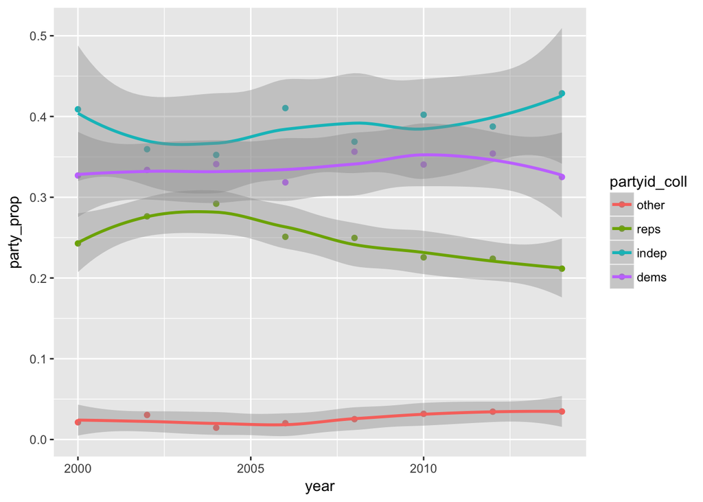

```r
partyid_trend <- gss_cat %>%
  mutate(partyid_coll = fct_collapse(partyid,
                                     dems = c("Strong democrat", "Not str democrat"),
                                     reps = c("Strong republican", "Not str republican"),
                                     indep = c("Independent", "Ind,near rep", "Ind,near dem"),
                                     other = c("No answer", "Don't know", "Other party")))

party_trend_plot <- partyid_trend %>%
  group_by(year) %>%
  count(partyid_coll) %>%
  mutate(party_prop = n/sum(n))

ggplot(party_trend_plot, aes(x = year, y = party_prop, color = partyid_coll)) +
  geom_point() +
  geom_smooth()
```

The proportion of Republicans has steadily decreased over the years from approximately 2004 to 2014. The proportion of Independent identifying people has seen a slight increase during approximately the same period. The proprtion of Democrats mostly did not change notwithstanding a slight increase in 2010.

## 9

```r
levels(gss_cat$rincome)
```

```
##  [1] "No answer"      "Don't know"     "Refused"        "$25000 or more"
##  [5] "$20000 - 24999" "$15000 - 19999" "$10000 - 14999" "$8000 to 9999"
##  [9] "$7000 to 7999"  "$6000 to 6999"  "$5000 to 5999"  "$4000 to 4999"
## [13] "$3000 to 3999"  "$1000 to 2999"  "Lt $1000"       "Not applicable"
```

```r
gss_cat %>%
  mutate(rincome_cat = fct_collapse(rincome,
               other = c("No answer", "Don't know", "Refused", "Not applicable"),
               `lt1000` = c("Lt $1000"),
               `1000-4999` = c("$1000 to 2999", "$3000 to 3999", "$4000 to 4999"),
               `5000-9999` = c("$5000 to 5999", "$6000 to 6999", "$7000 to 7999", "$8000 to 9999"),
               `10000-14999` = c("$10000 - 14999"),
               `15000-19999` = c("$15000 - 19999"),
               `20000-24999` = c("$20000 - 24999"),
               `25000higher` = c("$25000 or more")))
```

```
## # A tibble: 21,483 x 10
##     year marital     age race  rincome   partyid   relig   denom   tvhours
##    <int> <fct>     <int> <fct> <fct>     <fct>     <fct>   <fct>     <int>
##  1  2000 Never ma…    26 White $8000 to… Ind,near… Protes… Southe…      12
##  2  2000 Divorced     48 White $8000 to… Not str … Protes… Baptis…      NA
##  3  2000 Widowed      67 White Not appl… Independ… Protes… No den…       2
##  4  2000 Never ma…    39 White Not appl… Ind,near… Orthod… Not ap…       4
##  5  2000 Divorced     25 White Not appl… Not str … None    Not ap…       1
##  6  2000 Married      25 White $20000 -… Strong d… Protes… Southe…      NA
##  7  2000 Never ma…    36 White $25000 o… Not str … Christ… Not ap…       3
##  8  2000 Divorced     44 White $7000 to… Ind,near… Protes… Luther…      NA
##  9  2000 Married      44 White $25000 o… Not str … Protes… Other         0
## 10  2000 Married      47 White $25000 o… Strong r… Protes… Southe…       3
## # ... with 21,473 more rows, and 1 more variable: rincome_cat <fct>
```

I collapsed rincome into intervals of 5000 starting with non informative reports, lower than 1000, going up to 24999 and 25000 and higher.

# 2 R4DS Chapter 16

## 1

```r
library(nycflights13)

#from book
make_datetime_100 <- function(year, month, day, time) {
  make_datetime(year, month, day, time %/% 100, time %% 100)
}

flights_dt <- flights %>%
  filter(!is.na(dep_time), !is.na(arr_time)) %>%
  mutate(
    dep_time = make_datetime_100(year, month, day, dep_time),
    arr_time = make_datetime_100(year, month, day, arr_time),
    sched_dep_time = make_datetime_100(year, month, day, sched_dep_time),
    sched_arr_time = make_datetime_100(year, month, day, sched_arr_time)
  ) %>%
  select(origin, dest, ends_with("delay"), ends_with("time"))

#compare
flights_dt <- flights_dt %>%
  mutate(dep_delay_conv = (dep_time - sched_dep_time)/60)

table(ifelse(flights_dt$dep_delay_conv == flights_dt$dep_delay,
             "equal", "not equal"))
```

```
##
##     equal not equal
##    326858      1205
```

Using code from the book to convert departure and arrival times, I examined whether the newly converted delay times are the same as the difference in departure and scheduled departure times. After doing the conversion and converting to minutes to match the original departure delay, the two columns are mostly the same.

## 2

```r
flights_dt <- flights_dt %>%
  mutate(air_time_conv = arr_time - dep_time,
         air_time_conv2 = sched_arr_time - sched_dep_time)

table(ifelse(flights_dt$air_time_conv2 == flights_dt$air_time,
             "equal", "not equal"))
```

```
##
##     equal not equal
##       599    326747
```

It seems that most of the flights’ air times do not equal the time difference between arrival time and departure time. I tried to find the air time using scheduled arrival and departure times and non-scheduled arrival and departure times. Neither yielded results that showed it was equivalent to the original air time.

## 3

```r
d1 <- "January 1, 2003"
d2 <- "2013-Mar-07"
d3 <- "06-Jun-2017"
d4 <- c("August 9 (2015)", "July 1 (2015)")
d5 <- "12/29/14" # Dec 29, 2014

mdy(d1)
```

[output not shown]

```r
ymd(d2)
```

```
## [1] "2013-03-07"
```

```r
dmy(d3)
```

```
## [1] "2017-06-06"
```

```r
mdy(d4)
```

```
## [1] "2015-08-09" "2015-07-01"
```

```r
mdy(d5)
```

```
## [1] "2014-12-29"
```

## 4

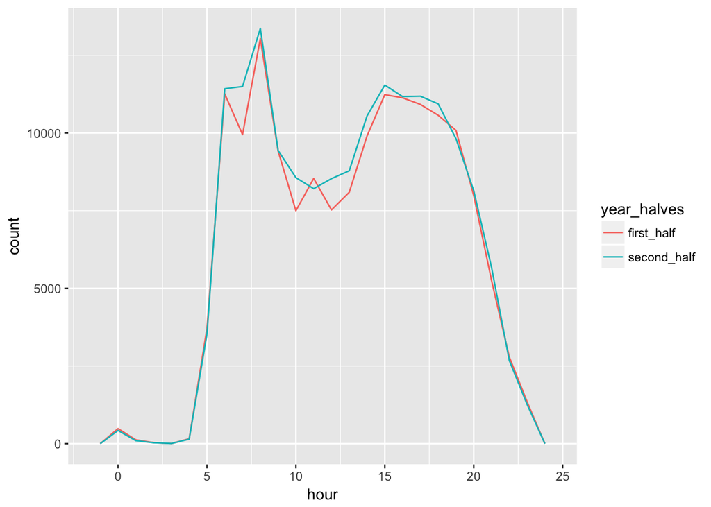

```r
flight_halves <- flights_dt %>%
  mutate(hour = hour(dep_time),
         year_halves = ifelse(month(dep_time) <= 6, "first_half", "second_half"))

ggplot(flight_halves, aes(hour, group = year_halves, color = year_halves)) +
  geom_freqpoly(binwidth = 1)
```

The distribution seems to trace out the flights throughout the day similarly between the first half and second half of the year. The distributions are roughly the same between the two halves of the year with the second half having slightly less variable than the first half around 12 noon on a day.

## 5

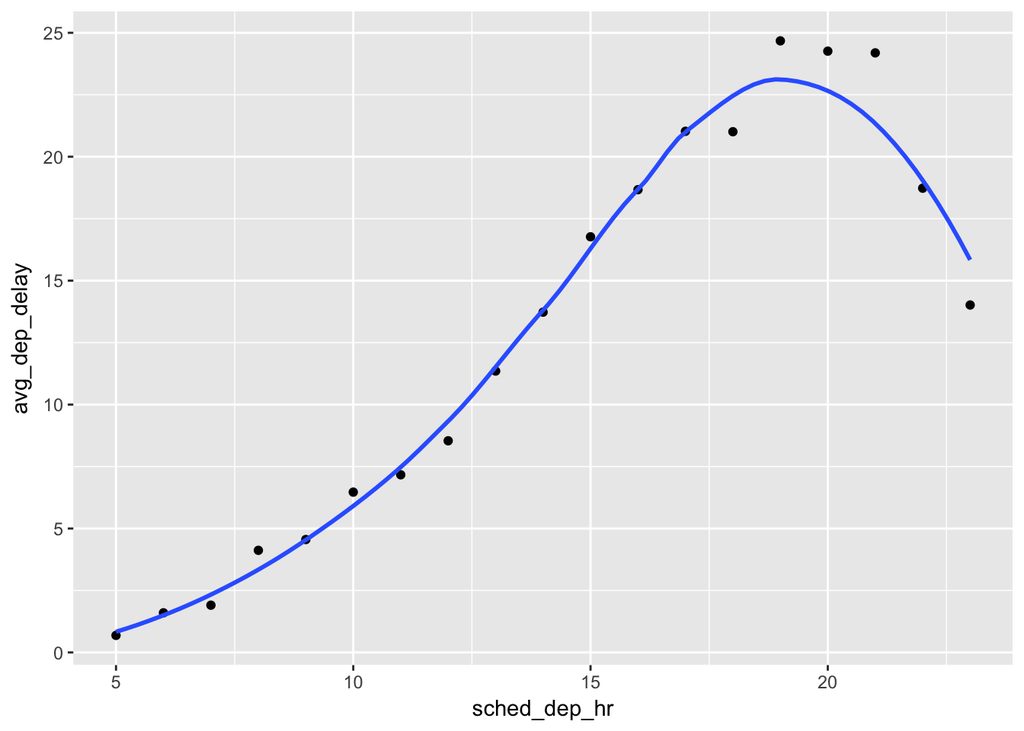

```r
avg_delay_day <- flights_dt %>%
  mutate(sched_dep_hr = hour(sched_dep_time)) %>%
  group_by(sched_dep_hr) %>%
  summarise(avg_dep_delay = mean(dep_delay))

ggplot(avg_delay_day, aes(x = sched_dep_hr, y = avg_dep_delay)) +
  geom_point() +
  geom_smooth(se = FALSE)
```

The graph shows departure delays occur more as the day goes on in an exponential growth rate and peaks in the evening at around 7 or 8 pm and then drops after those evening hours. We should use sched_dep_time in order to measure against real departure delays because comparing scheduled departure to average delays would give a true representation of delays. Using actual departure time would underestimate the average delays since delays are already built into the departure time.

## 6

```r
flights_dt %>%
  mutate(day_leave = wday(sched_dep_time)) %>%
  group_by(day_leave) %>%
  summarise(avg_dep_delay = mean(dep_delay, na.rm = TRUE)) %>%
  arrange(avg_dep_delay)
```

```
## # A tibble: 7 x 2
##   day_leave avg_dep_delay
##       <dbl>         <dbl>
## 1      7.00          7.62
## 2      3.00         10.6
## 3      1.00         11.5
## 4      4.00         11.7
## 5      6.00         14.7
## 6      2.00         14.7
## 7      5.00         16.1
```

To minimise the chance of a delay, you should leave on the 7th day of the week, Saturday because it has the shortest average departure delay time.

## 7

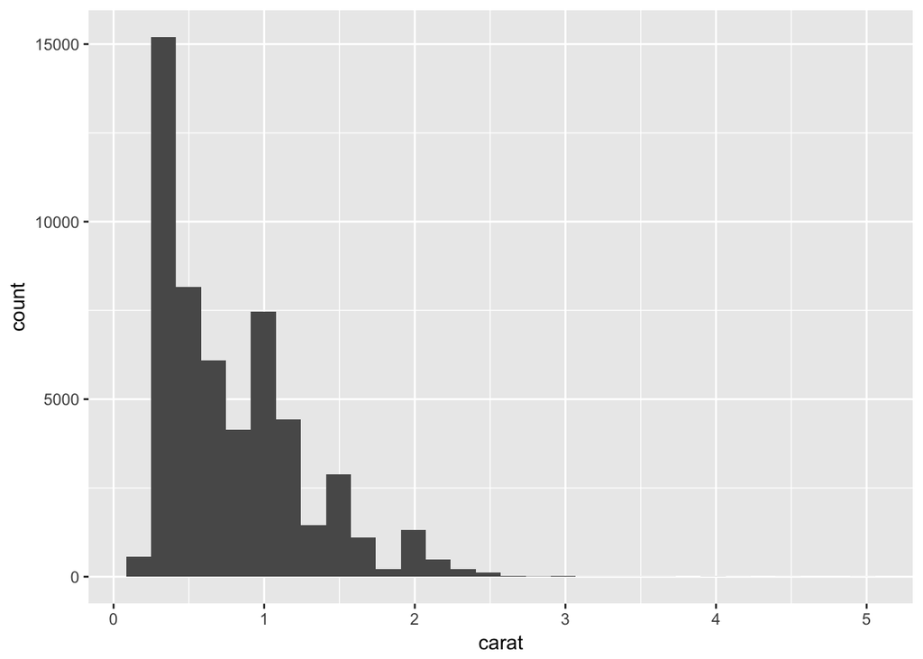

```r
ggplot(diamonds, mapping = aes(x= carat)) +
  geom_histogram()
```

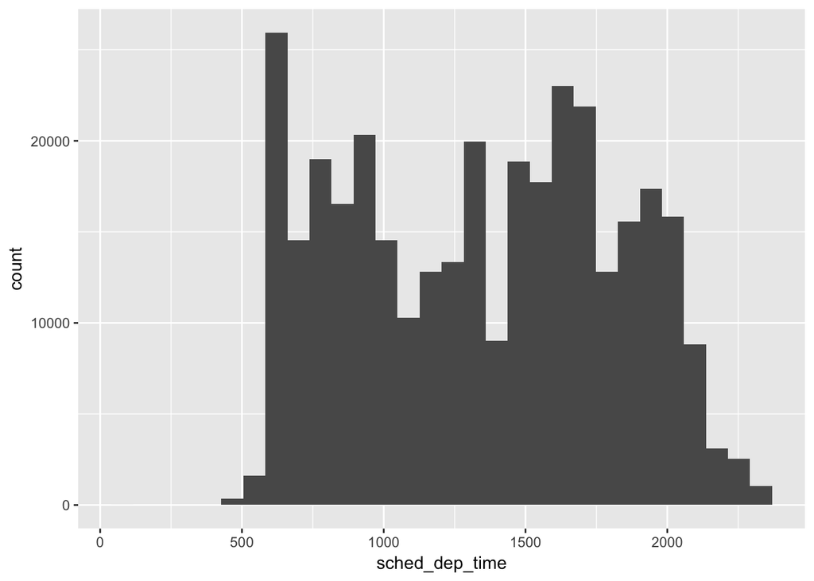

```r
ggplot(flights, mapping = aes(x = sched_dep_time)) +
  geom_histogram()
```

In both diamonds and flights, the carats and sched_dep_time both have more values at rounded off numbers. Carats are concentrated at 0.5 1, 1.5, and 2 carats. Scheduled departure times seem to be concentrated at intervals of 15 minutes, or quarter hour, of each hour.

## 8

```r
dates_vec_2015 <- ymd("2015-01-01") + months(0:11)
dates_vec_2018 <- ymd("2018-01-01") + months(0:11)
```

## 9

```r
age_func <- function(birthday) {
  bday_converted <- ymd(birthday)
  my_age <- today() - bday_converted
  my_age <- as.duration(my_age)
  print(my_age)
}

age_func(19901223)
```

```
## [1] "857692800s (~27.18 years)"
```

I wrote a function that converts my birthday in the ymd format to years by subtracting today’s date and the reformatted birthday and then converting it from the difference in days to years using as.duration.

## 10

```r
locale("zh")
```

```
## <locale>
## Numbers:  123,456.78
## Formats:  %AD / %AT
## Timezone: UTC
## Encoding: UTF-8
## <date_names>
## Days:   星期日 (周日), 星期一 (周一), 星期二 (周二), 星期三 (周三), 星期四
##         (周四), 星期五 (周五), 星期六 (周六)
## Months: 一月 (1月), 二月 (2月), 三月 (3月), 四月 (4月), 五月 (5月), 六月
##         (6月), 七月 (7月), 八月 (8月), 九月 (9月), 十月 (10月),
##         十一月 (11月), 十二月 (12月)
## AM/PM:  上午/下午
```

```r
parse_date("十二月 23 1990", "%B %d %Y", locale = locale("zh"))
```

```
## [1] "1990-12-23"
```

```r
locale("fi")
```

```
## <locale>
## Numbers:  123,456.78
## Formats:  %AD / %AT
## Timezone: UTC
## Encoding: UTF-8
## <date_names>
## Days:   sunnuntaina (su), maanantaina (ma), tiistaina (ti), keskiviikkona
##         (ke), torstaina (to), perjantaina (pe), lauantaina (la)
## Months: tammikuuta, helmikuuta, maaliskuuta, huhtikuuta, toukokuuta,
##         kesäkuuta, heinäkuuta, elokuuta, syyskuuta, lokakuuta,
##         marraskuuta, joulukuuta
## AM/PM:  ap./ip.
```

```r
parse_date("joulukuuta 23 1990", "%B %d %Y", locale = locale("fi"))
```

```
## [1] "1990-12-23"
```

In Chinese and Finnish, I printed a date object with month, calendar day, and year.